# Complex Arguments

Philosophy 101 - Class 05

Brian Weatherson

weath@umich.edu

University of Michigan

September 12, 2023

# Chains of Reasoning

## Multi-Step Arguments

### Task: What are the premises and conclusion in this argument?

> I know the streets are wet. Everyone who walked into class was dripping wet. So it’s raining. So the streets must be wet.

## Multi-Step Arguments

### It’s a trick question

There are three steps here.

1. Everyone who walked into class was dripping wet.
2. It’s raining.
3. The streets are wet.

## Argument Maps

To present arguments like this, I’m going to use a new format, called **argument maps**.

This is, by philosophy standards, a very new idea - it was only developed in the last 20 years. (If Plato didn’t know about an idea, we sometimes treat it as new.)

The next slide has one way we could present the argument from the last slide.

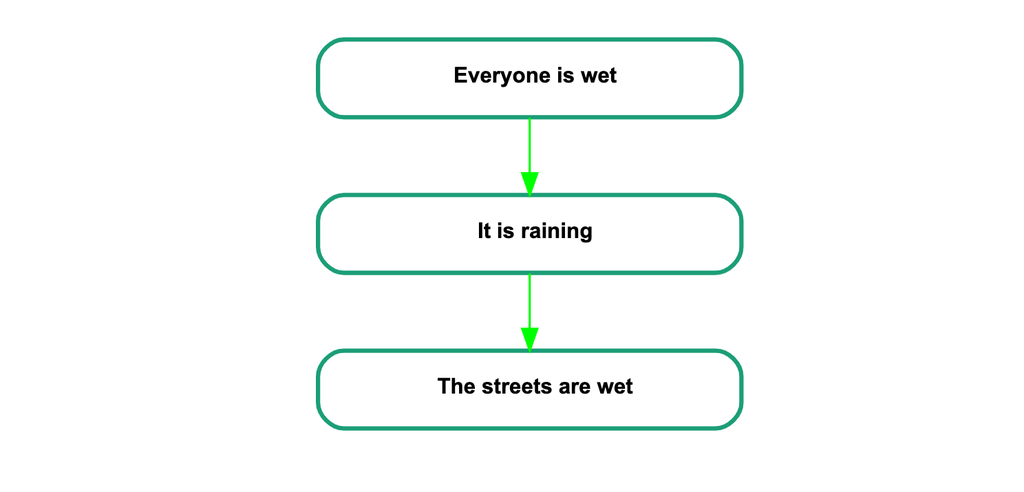

## Argument Maps

For reasons that I’ll get to shortly, it’s usually helpful to mark explicitly where an argument step occurs.

I’ll do these with small circles. So the revised version of the map looks like this.

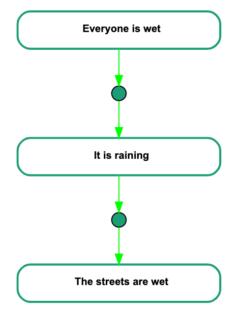

## Dots

We’ll eventually have three reasons to include these dots.

One, that I actually won’t make a huge use of, is that you can expand them to describe what kind of argument that you’re using.

I do that on the next slide.

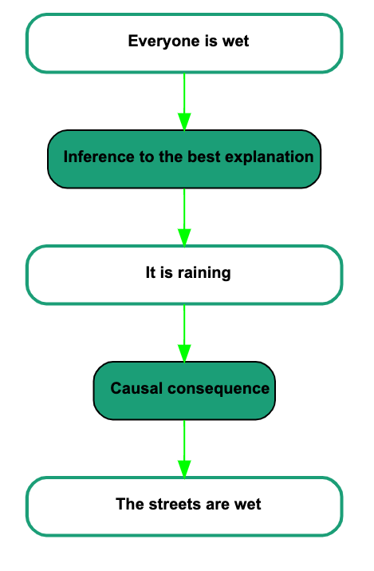

## Dots and Arguments

Another reason is that it lets you distinguish the following two cases.

1. Someone offers an argument with two premises for a particular conclusion.
2. Someone offers two distinct arguments, each with one premise, for the same conclusion.

## Multiple Arguments

This is something that happens a lot in philosophy.

A philosophy paper often won’t just develop one argument for its main conclusion.

It will offer multiple reasons to believe the one conclusion.

## Single Argument with Two Premises

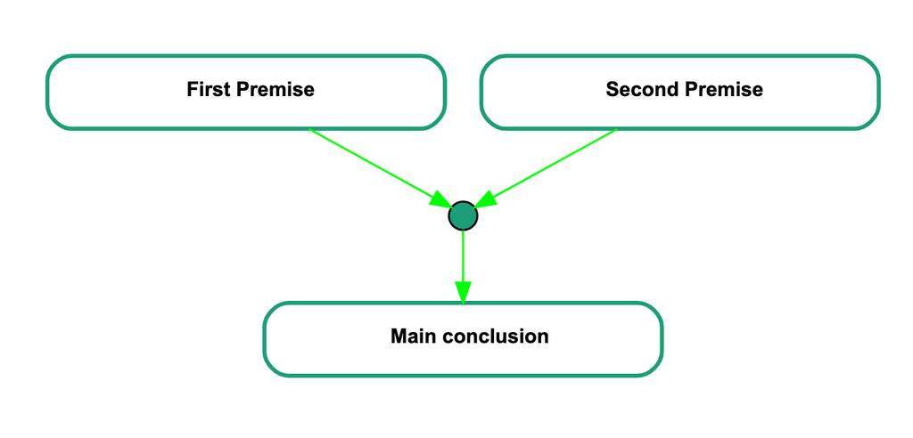

The two arrows into the dot mean that these premises combine in the argument

## Two Arguments with a Single Premise

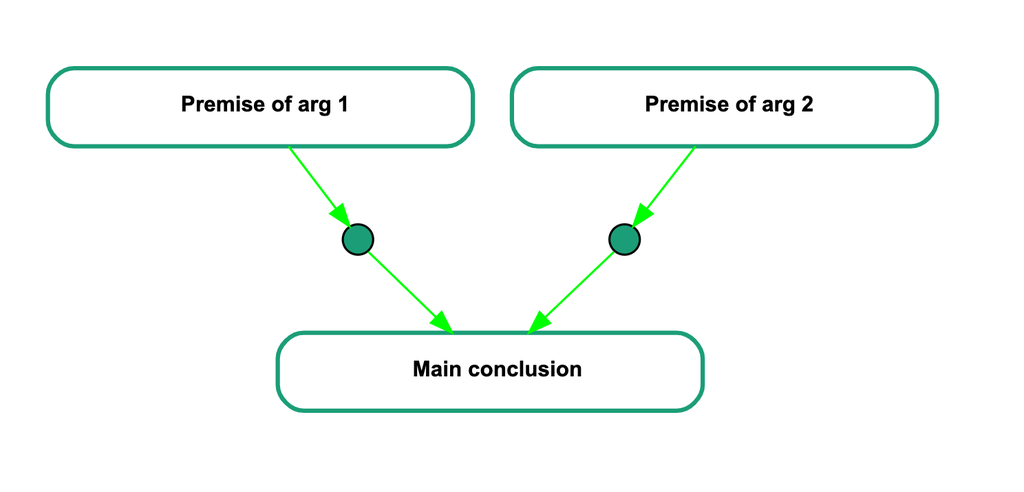

The dots mean there are two arguments

## The Difference in Practice

It isn’t always easy to tell when someone is offering one or the other of these argument forms.

The main thing we do is use the **principle of charity**.

If they offer P1 and P2 as premises, and neither of them on their own supports the conclusion, we should assume that they mean them to combine.

## The Difference in Practice

There are also signs that an author can use to indicate which of the two types they have in mind.

- If they explicitly refer to the **conjunction** of the two premises, e.g., they say “From this premise and that premise it follows that…”, then they probably mean to indicate a single argument.
- If they say “From this premise, conclusion, and **also** this premise implies/supports…” they probably mean to offer two arguments.

## The Difference in Practice

Which kind of argument form the speaker is offering is important for thinking about which kinds of responses to their argument are going to work.

But that’s something we’ll deal with more next time, when we look in more details at the ways in which one can respond to arguments.

## An Example from UMich-GPT

I tried to get UMich-GPT to give me examples of the two things we’ve just discussed.

And it went 1-for-2; it did ok on getting two distinct arguments in a paragraph.

The morality of consuming meat has been widely debated, with several arguments indicating that it may be deemed as immoral. Firstly, one of the central ethical objections against meat consumption relates to animal rights and cruelty. Numerous animal species are kept in unlively conditions in industries for meat production, often subjected to pain and suffering before being slaughtered for food. This stands against their inherent right to a respectful and pain-free existence. Secondly, the environmental implications of meat production also raises moral concerns. The farming industry, especially livestock, contributes significantly to deforestation, water pollution, and greenhouse gas emissions, which directly impact climate change. Hence, endorsing meat consumption could be seen as supporting practices that threaten the sustainability of the planet for future generations.

## An Example from UMich-GPT

No idea where ‘unlively’ came from. That’s just weird.

I also asked it for a two premise argument for the same conclusion, and it also gave me two arguments.

Then I asked it to turn the paragraph on the previous slide into the kind of maps I’ve been showing you. And the result (which is wrong) is on the next slide.

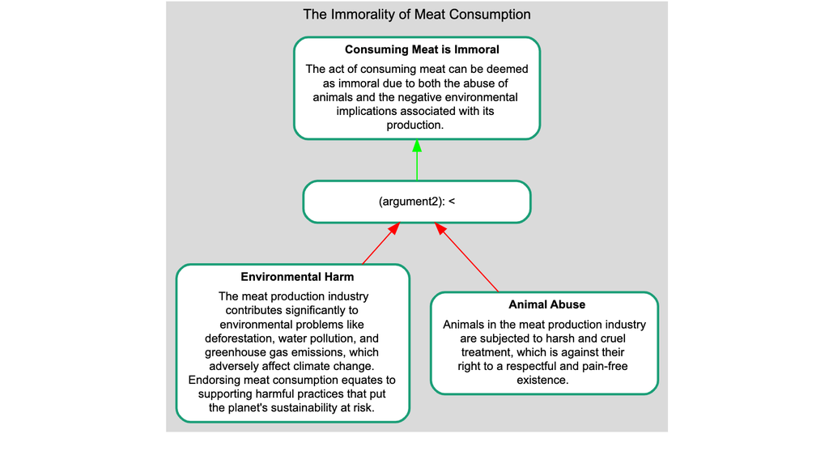

## GPT Isn’t Quite Ready for Prime Time

Of course that isn’t right; these are two different arguments, not a single argument.

Anyway, this stuff is hard. We’ll come back on Thursday to ways in which it’s even harder than this sounds.

To be honest, I was surprised by how badly GPT did on this task. More on this to follow.

# Direct and Assumed

## A Simple Argument

> We shouldn’t go to that hamburger place. My friend went to the last restaurant that the guy who owns it ran, and he got food poisoning. So we’ll get sick if we go there.

Question: What’s the conclusion of this argument.

1. We shouldn’t go to that hamburger place.
2. My friend went to the last restaurant that the guy who owns it ran, and he got food poisoning.
3. We’ll get sick if we go to that hamburger place.

## A Simple Argument

Hopefully everyone got the conclusion. Here’s a (slightly) harder question.

Question: What’s the **direct** support for that conclusion, i.e., the thing that you are meant to reason from to the conclusion.

1. We shouldn’t go to that hamburger place.
2. My friend went to the last restaurant that the guy who owns it ran, and he got food poisoning.
3. We’ll get sick if we go to that hamburger place.

## Two-Part Argument

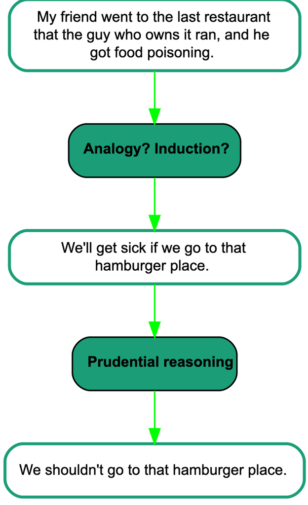

The map of the argument

## Direct Support

We’ll get sick etc **directly supports** the conclusion.

My friend went to the last restaurant etc does **not** directly support the conclusion. It indirectly supports it, by supporting something else.

## Assumption

I won’t do this with iclicker, but there is another kind of question we can ask. What do each of the steps here **assume**?

The second step is fairly easy - it assumes that **it is bad to get sick**.

This might seem so obvious, and there’s a reason that I left it out, but without it the argument fails.

## Assumption

That is very much not to say that the person giving the argument has to say it. Often it’s best to leave unspoken assumptions unspoken.

But still, it is something that (a) the person making the argument clearly believes, and (b) without it, their argument fails.

## Assumption

There is also an assumption or two behind the first part, thought it’s a little harder to say what it is.

That’s in part because it’s not clear exactly what the argument form is. (I included this on the map.)

But maybe the argument assumes something like **Whether you get sick at a restaurant is largely explained by who owns the restaurant**, or **Restaurants with the same owner are analogous, at least with respect to illness-causing**.

## Changing the Argument

One of the things that can help to see what is being assumed in an argument is comparing the argument to a very slightly changed one. If the changed argument is worse than the original, that tells you something about what is being assumed in the original. So consider this version.

> We shouldn’t go to that hamburger place. My friend went to the last restaurant that was at that location, and he got food poisoning. So we’ll get sick if we go there.

## Assumptions

These aren’t always easy to spot.

But they are very important in philosophy. A lot of disagreements come from someone rejecting a step of an argument that someone else thought was too obvious to even mention.

And a lot of philosophical progress comes from looking at places where people had gotten stuck in their reasoning, and seeing the assumptions they had made.

# The List of Forms

## Bonus Content 1

### We might not get to this

I hope to get through this material in lecture, but if we don’t, we don’t.

It’s a bit relevant to Hume, and if we don’t get to it now, we’ll come back to it then.

## Five Argument Forms

### We talked about these last time

1. Enumerative induction
2. Analogical inference
3. Inference to the best explanation
4. Causal inference
5. Testimony

## Four Questions

### Ideally we’d be able to say ‘yes’ to all four

1. Is every one of these a good form of inference?
2. Is the list non-redundant?
3. Is every one of them unified?
4. Is this it, is that all the forms?

## Four Questions

### With my answers

1. Is every one of these a good form of inference? yes
2. Is the list non-redundant? no
3. Is every one of them unified? no
4. Is this it, is that all the forms? no

## Redundancy

### Explanation is causal explanation

First, it’s important to note that everything in the next few slides is **controversial**. Philosophy doesn’t always have clear answers.

But I think, following work by Michigan’s Peter Railton, that explanation is causal explanation.

So causal inference and inference to the best explanation are sort of the same thing.

## Unification

### Internal and External Induction

I also think that we should think of inference out of a group (lots of campuses with coffee shops, so next campus has a coffee shop) and inference into a group (half of UM undergrads are from Michigan, so it’s 50/50 this UM undergrad is from Michigan) as distinct forms of inference.

They have somewhat different failure conditions, for example.

## Completeness

### Moral, analytical, etc.

Here are two other kinds of inference we might use.

1. **Moral Inference**: Inferring from the description of a situation to a moral evaluation of it.
2. **Analytical Inference**: Inferring from the description of a situation to the applicability (or non-applicability) of a high-level concept to it.

Note the next slide is going to be more violent than most of our examples.

## Moral Inference

### Don’t burn cats

1. Some teenagers have surrounded a scared cat, and are trying to pour gasoline on it and set it on fire.
2. Therefore, the teenagers are trying to do something wrong.

Actually, maybe even the attempt is wrong, so the conclusion could be stronger.

I think (controversially!) that this is good inference but doesn’t fit any of these categories.

## Moral Inference

### Ought from an is

This is controversial because a lot of philosophers endorse the principle: **No ought from an is**.

This is often associated with the 18th century Scottish philosopher David Hume, who we’re going to hear a lot more about.

## Moral Inference

### How moral inference works on Hume’s picture

This doesn’t mean those folks are ok with cat torture.

It means they think the inference I showed you is **incomplete**. It is what’s sometimes called an **enthymeme**.

That means there is a hidden premise, something about the morality of cat torture, that I assumed but didn’t say, and that’s the real argument.

## Analytic Inference

### An old example, from 9th century Indian philosophy

A traveller is walking through the hills. He sees a black cloud over the next hill. It looks a lot like smoke, and he infers that there’s a fire over the hill. There is a fire, but that cloud isn’t smoke. It’s some flies that have gathered over the fire.

## Poll

Does the traveller know that there is a fire over the hill?

1. Yes
2. No
3. Unsure

## Analytic Inference

### How did you answer that question

If you answered ‘Yes’, or ‘No’ (which Dharmottara wanted you to answer), you must have inferred that from the description of the case.

Again, it’s a bit controversial, but I think such inferences are warranted, and don’t fit into any of the categories we’ve had so far.

## Pramāṇa

### An organising concept for Indian philosophy

It would be very good to have a list of inference forms where we could answer ‘yes’ to all four questions: reasonableness, non-redundancy, unification, and completeness.

But it was very central to Indian philosophy, where the question of which methods were pramāṇas (means of knowledge/means of proof) was hotly debated, and often definitional of one school or other.

# Arguing for a Premise

## Bonus Content

### We might not finish this, and if we don’t we won’t come back to it

Most everything I’m saying this week about arguments is useful whether you’re doing philosophy, biology, English literature, or any other subject in the university.

But the pattern I’m about to describe comes up much more in philosophy than other areas.

## Arguing for a Premise

### Too much covering all the bases

Sometimes, a philosopher will be in the following situation.

- They have a nice argument for a conclusion $C$, and one of the premises is $P$.
- $P$ is very plausible, and like 80% of readers will accept it.
- But 20% of them won’t, and for those 20%, the philosopher tries to come up with an argument for $P$.

## Arguing for a Premise

### Too much covering all the bases

So far this might seem familiar: $P$ goes from a premise to an intermediate conclusion.

But often enough in philosophy the following two things happen.

1. $P$ was actually a plausible premise; they should be allowed to have it as a starting point.
2. The argument for $P$ wasn’t actually very good, and should be rejected.

## Arguing for a Premise

### Really two arguments

I think in these cases, we should think of the philosopher as offering **two arguments**.

One of them starts with $P$, one of them starts with the argument for $P$.

## A Real Life Case

In the early 1960s a philosopher at Wayne State University, Edmund Gettier, independently rediscovered cases like Dharmottara’s case of the traveller. (He didn’t know about Dharmottara, or afaik any other Indian philosophy.)

And he noted that they were problems for the following otherwise plausible theory of knowledge.

To know a proposition is to have a reasonable, true, belief in the proposition.

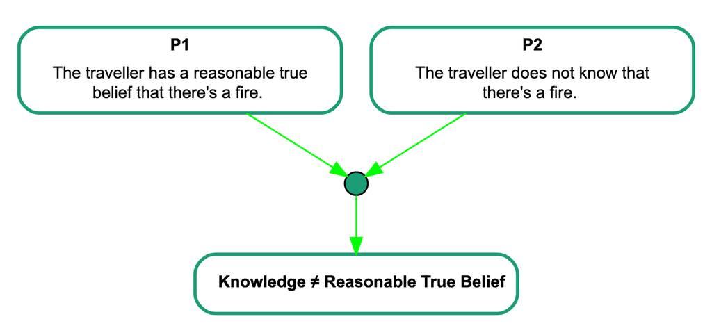

## Gettier’s Argument

But Gettier at least did not stop there. He threw in, almost as an afterthought, the following argument for P2. (Actually for the equivalent of P2 in his, more convoluted, example.)

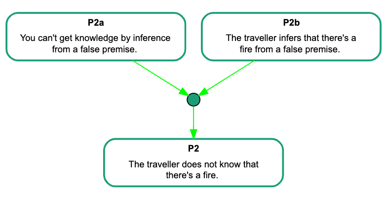

## Knowledge and Falsity

### Big controversial claims

And P2a, that you can’t get knowledge by inference from a false premise, is really controversial.

Possible counterexample: 19th century engineers used Newtonian physics in their calculations, which is only approximately true, i.e., not actually true.

But they knew a lot of things about which bridges would stand up.

## A Convoluted Argument Map

### Arguing for premises makes everything messy

It’s really tricky to map out the argument here.

This isn’t just because it’s hard to draw the map, it’s hard to make sense of the actual argument. I’ve tried on the next slide. (If you can’t read it; I’ll put these on Canvas. It is very small.)

And I think we’ll get the same issue whenever someone puts forward a premise, and then throws in an argument for it.

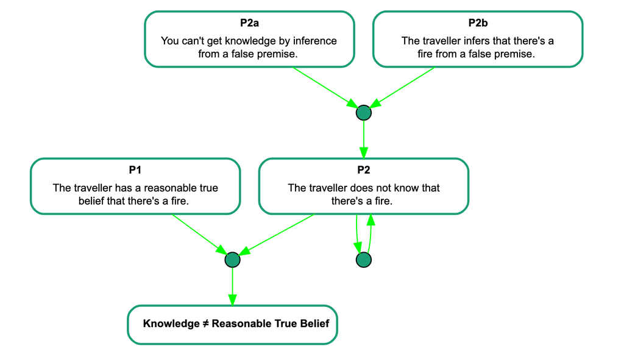

# For Next Time

## Objection!

We’ll look at ways to object to arguments